# instructor recap notes - lec 32

2023-12-13

```r
rm(list=ls())
# load the required libraries
library(tidyverse)
library(caret)
library(glmnet)
library(ggplot2)
```

## 0. Random quiz

How many modules have we covered in this course?

- Git and GitHub!
- R basics
  - data types
  - programming basics
  - basic data wrangling
  - pipe operator
- Data Visualization
  - ggplot2
  - maps
  - principles
- Advanced wrangling
  - tidy and reshape data
  - join table
  - date and times
- Probablity and Regression
  - linear regression
  - confounding
- Machine learning!
  - workflow of machine learning
  - types of prediction
    - classification
    - regression
  - machine learning algorithms
    - generalized linear models (linear, logistic, …)
    - naive bayes
    - knn
    - lda, qda
    - trees and forest
    - regularization: lasso, ridge, elastic net
    - unsupervised: PCA
  - machine learning metrics / techniques
    - confusion matrix
    - mse; rmse
    - roc; auc
    - cross validation (tune parameters)

## 1. Principle component analysis

### 1.1 Overview

Principal Component Analysis (PCA) is a statistical technique used for dimension reduction. It transforms the data into a new coordinate system, reducing the number of dimensions without losing much information (variability). This method is useful in pattern recognition, data compression, and exploratory data analysis.

#### Key Concepts

- **Variance and Covariance**: PCA identifies the directions (principal components) along which the variance in the data is maximal.
- **Eigenvalues and Eigenvectors**: These are used in PCA to determine the principal components.
- **Dimension Reduction**: PCA reduces the dimensionality of data by projecting it onto a lower-dimensional subspace.

### 1.2 How to implement in R

We will use the `iris` dataset available in R to demonstrate PCA. This dataset contains measurements for 150 iris flowers from three different species. You can use this command `?iris` for more details about this dataset.

```r
# Load the iris dataset
data(iris)

# Preview the data
head(iris)
```

```
##   Sepal.Length Sepal.Width Petal.Length Petal.Width Species
## 1          5.1         3.5          1.4         0.2  setosa
## 2          4.9         3.0          1.4         0.2  setosa
## 3          4.7         3.2          1.3         0.2  setosa
## 4          4.6         3.1          1.5         0.2  setosa
## 5          5.0         3.6          1.4         0.2  setosa
## 6          5.4         3.9          1.7         0.4  setosa
```

```r
# Performing PCA
iris_pca <- prcomp(iris[,1:4], center = TRUE, scale. = TRUE)

# Summary of PCA
summary(iris_pca)
```

```
## Importance of components:
##                           PC1    PC2     PC3     PC4
## Standard deviation     1.7084 0.9560 0.38309 0.14393
## Proportion of Variance 0.7296 0.2285 0.03669 0.00518
## Cumulative Proportion  0.7296 0.9581 0.99482 1.00000
```

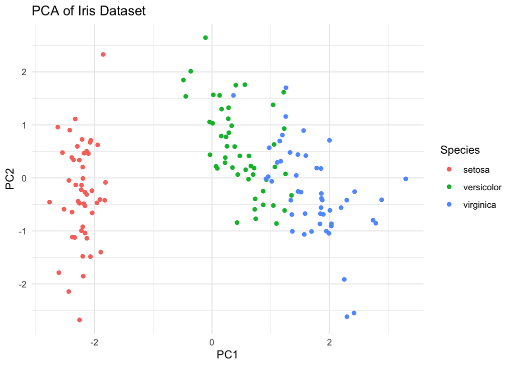

```r
# Creating a data frame for ggplot
pca_data <- data.frame(iris_pca$x, Species = iris$Species)

# Plotting
ggplot(pca_data, aes(x = PC1, y = PC2, color = Species)) +
  geom_point() +
  theme_minimal() +
  ggtitle("PCA of Iris Dataset")
```

**Interpretation**

The plot shows how the iris dataset is spread across the first two principal components. We can observe how different species cluster differently, indicating that PCA effectively reduces dimensions while preserving species separability.

## 2. Today’s lecture

- Today: cross validation, next steps
- Homework 4 (two late days)